# **Final Project**

Lara Mijic | November 26, 2023

## Task 1: Libraries, Importing the Dataset, and High Level Exploration of the Data

### Loading Libraries

```python
import pandas as pd
import numpy as np
import matplotlib.pyplot as plt
import seaborn as sns
import math

import sklearn
from sklearn import tree
from sklearn import metrics
from sklearn.model_selection import GridSearchCV, train_test_split, cross_validate, StratifiedKFold
from sklearn.tree import DecisionTreeClassifier, plot_tree
from sklearn.svm import SVC
from sklearn.neural_network import MLPClassifier
from sklearn.neighbors import KNeighborsClassifier
from sklearn.dummy import DummyClassifier
from sklearn.metrics import accuracy_score, precision_score, recall_score, f1_score, confusion_matrix
from sklearn.preprocessing import StandardScaler
```

**What libraries are and why we need to import them:** Libraries are pre-written code that extends the functionality of Python. They provide functions that can be used without having to write the code from scratch. We need to import these libraries because Python does not have these functions built-in. Python libraries are good for data science, data visualization, machine learning, math, and more.

**What each Library Does:**

*Pandas* - This is a data manipulation and analysis library. With this library, you can manipulate numerical tables and time series data using the operations and data structures it offers. In this project, I have used Pandas primarily for converting my data into Dataframes instead of lists, so that the outputted information is easier to read. I also used functionality from the Pandas library to read in the intial datafile.

*Numpy* - This library deals with matrices and large multi-dimensional arrays as well as other numerical operations. In this project specifically, an example of how I used functionality from the Numpy library was to use the .dtype attribute to get the datatype of the elements that were stored in numpy arrays.

*Matplotlib* - This library allows for creating 2D charts and other visualizations. It can also be used to create interactive figures. In this project, I used matplotlib to create the visuals for stacked bar charts in Task 5.

*Seaborn* - This library is based on Matplotlib and is also used to create charts with an emphasis on statistical graphics. It is a popular library for data exploration. In this project, I used seaborn to plot histograms and bar charts to explore the columns in the dataset in more depth. I also used this library to create a pairplot and a heatmap to explore correlations between columns and the target variable.

*Sklearn* - This library is a machine learning library that was built on SciPy, Numpy, and Matplotlib. It is useful for regression, classification, clustering, dimensionality reduction, model selection, and preprocessing. In this project, this is the library I used to help build the models in Task 7. In the library import up above I imported DecisionTreeClassifier, SVC, MLP, and KNN for the models as well as metrics to evaluate the models. This library also allowed me to import the GridsearchCV, which was used to find the best models.

### Importing Data

```python
p1_data = pd.read_csv("https://raw.githubusercontent.com/matthewpecsok/4482_fall_2022/main/data/census.csv")
```

A dataframe is a data structure that organizes data into columns and rows in a table, which resembles a spreadsheet format. Using a dataframe makes the data much more readable and interpretable. Additionally, a dataframe could even be made to be interactive, so that the viewer can sort the dataframe by a certain column or feature.

### Dataframe Shape

```python
p1_data.shape
```

```
(32561, 15)
```

This dataset has 32,561 rows of data and 15 columns.

### Dataframe Info

```python
p1_data.info()
```

```
<class 'pandas.core.frame.DataFrame'>
RangeIndex: 32561 entries, 0 to 32560
Data columns (total 15 columns):
 #   Column          Non-Null Count  Dtype
---  ------          --------------  -----
 0   age             32561 non-null  int64
 1   workclass       32561 non-null  object
 2   fnlwgt          32561 non-null  int64
 3   education       32561 non-null  object
 4   education-num   32561 non-null  int64
 5   marital-status  32561 non-null  object
 6   occupation      32561 non-null  object
 7   relationship    32561 non-null  object
 8   race            32561 non-null  object
 9   sex             32561 non-null  object
 10  capital-gain    32561 non-null  int64
 11  capital-loss    32561 non-null  int64
 12  hours-per-week  32561 non-null  int64
 13  native-country  32561 non-null  object
 14  y               32561 non-null  object
dtypes: int64(6), object(9)
memory usage: 3.7+ MB
```

Most of this data set has object types. See the code below for a breakdown.

### Count of Categorical Versus Numeric Columns

```python
object_count = 0
int64_count = 0

for column in p1_data.columns:
    if p1_data[column].dtype == 'O':
        object_count += 1
    elif p1_data[column].dtype == 'int64':
        int64_count += 1
```

```python
print(f"Number of object columns: {object_count}")
print(f"Number of int64 columns: {int64_count}")
```

```
Number of object columns: 9
Number of int64 columns: 6
```

60% of this data set contains object data types while the other 40% has numeric data types.

### Check For Nulls

```python
p1_data.isnull().sum()
```

```
age               0
workclass         0
fnlwgt            0
education         0
education-num     0
marital-status    0
occupation        0
relationship      0
race              0
sex               0
capital-gain      0
capital-loss      0
hours-per-week    0
native-country    0
y                 0
dtype: int64
```

This dataset has no null values. Therefore, I will not have to handle null values with any methods, such as removing the rows with null values or imputing the null values.

### Dataframe Aggregate Statistics

```python
p1_data.describe()
```

|  | age | fnlwgt | education-num | capital-gain | capital-loss | hours-per-week |
| --- | --- | --- | --- | --- | --- | --- |
| count | 32561.000000 | 3.256100e+04 | 32561.000000 | 32561.000000 | 32561.000000 | 32561.000000 |
| mean | 38.581647 | 1.897784e+05 | 10.080679 | 1077.648844 | 87.303830 | 40.437456 |
| std | 13.640433 | 1.055500e+05 | 2.572720 | 7385.292085 | 402.960219 | 12.347429 |
| min | 17.000000 | 1.228500e+04 | 1.000000 | 0.000000 | 0.000000 | 1.000000 |
| 25% | 28.000000 | 1.178270e+05 | 9.000000 | 0.000000 | 0.000000 | 40.000000 |
| 50% | 37.000000 | 1.783560e+05 | 10.000000 | 0.000000 | 0.000000 | 40.000000 |
| 75% | 48.000000 | 2.370510e+05 | 12.000000 | 0.000000 | 0.000000 | 45.000000 |
| max | 90.000000 | 1.484705e+06 | 16.000000 | 99999.000000 | 4356.000000 | 99.000000 |

The average age of those in this dataset is 38 years with 90 years being the max and 17 years of age being the minimum. Thus, there is a wide age range for this dataset. According to the census metafile in the project description, fnlwgt represents final weight, which is "controlled to independent estimates of the civilian noninstitutional population of the US." Among other things, fnlwgt is race, age, and sex. The metafile explains that people with similar weights should have similar demographic characteristics within the state from which they were sampled. The education-num likely coincides with the categorical variable education. From this overview, it looks like the majority of the values in the capital gain and capital loss columns are zero with a small percentage of values being over zero. The average hours-per-week are 40, which is the standard work week. The max hours-per-week are 99 and the minimum is 1.

### Head of the Dataframe

```python
p1_data.head()
```

|  | age | workclass | fnlwgt | education | education-num | marital-status | occupation | relationship | race | sex | capital-gain | capital-loss | hours-per-week | native-country | y |
| --- | --- | --- | --- | --- | --- | --- | --- | --- | --- | --- | --- | --- | --- | --- | --- |
| 0 | 39 | State-gov | 77516 | Bachelors | 13 | Never-married | Adm-clerical | Not-in-family | White | Male | 2174 | 0 | 40 | United-States | <=50K |
| 1 | 50 | Self-emp-not-inc | 83311 | Bachelors | 13 | Married-civ-spouse | Exec-managerial | Husband | White | Male | 0 | 0 | 13 | United-States | <=50K |
| 2 | 38 | Private | 215646 | HS-grad | 9 | Divorced | Handlers-cleaners | Not-in-family | White | Male | 0 | 0 | 40 | United-States | <=50K |
| 3 | 53 | Private | 234721 | 11th | 7 | Married-civ-spouse | Handlers-cleaners | Husband | Black | Male | 0 | 0 | 40 | United-States | <=50K |
| 4 | 28 | Private | 338409 | Bachelors | 13 | Married-civ-spouse | Prof-specialty | Wife | Black | Female | 0 | 0 | 40 | Cuba | <=50K |

The head of this dataframe further confirms my belief that the education column and education-num column go together as the number for Bachelors is consistently 13 and the numbers go down in value as the level of education goes down in value.

### Heatmap: Correlations Between all of the Columns

```python
cor = p1_data.corr(numeric_only=True)
```

```
[]
```

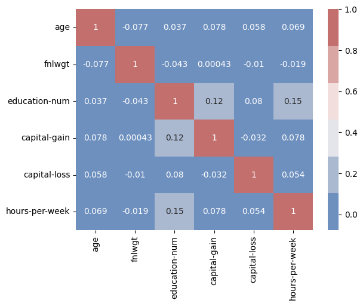

```python
sns.heatmap(cor,
            annot=True,
            cmap=sns.color_palette("vlag"),
        xticklabels=cor.columns,
        yticklabels=cor.columns)

plt.plot()
```

According to this correlation heatmap, it looks like there is very week correlation between all of the columns. Thus, we cannot see any trends between age and hours-per-week or capital-gain, for example.

## Task 2: Column by Column Exploration

### Create Counting Function

```python
def counting_values(dataframe, column_name):
  values = dataframe[column_name].value_counts()
  return values
```

This function will count each kind of value in each column to help determine which value in each column is the most or least prevelant.

### Function to Calculate Optimal Bin Size for Histograms Based on Sturges Rule

```python
def calculate_bin_size(n):
    result = 1 + 3.3 * math.log(n)
    return result
```

```python
n_value = 32561
```

```python
result = calculate_bin_size(n_value)
print(result)
```

```
35.28987275617938
```

### Age Column

**Age Datatype**

```python
p1_data['age'].dtype
```

```
dtype('int64')
```

**Age Summary Statistics**

```python
p1_data['age'].describe()
```

```
count    32561.000000
mean        38.581647
std         13.640433
min         17.000000
25%         28.000000
50%         37.000000
75%         48.000000
max         90.000000
Name: age, dtype: float64
```

**Age Histogram**

```python
age_values = counting_values(p1_data, 'age')
```

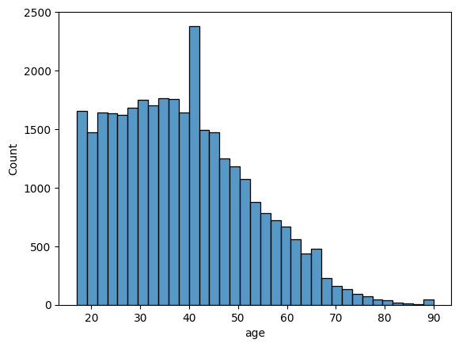

```python
sns.histplot(data=p1_data, x="age", bins=35)
```

Again, here we see that around the age of 40, the bin sizes are higher than most. Overall, the data seems more skewed towards the left in the younger age ranges, which makes sense as less older individuals will be working.

**Age Boxplot**

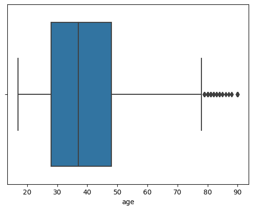

```python
sns.boxplot(x=p1_data["age"])
```

### Workclass Column

**Workclass Datatype**

```python
p1_data['workclass'].dtype
```

```
dtype('O')
```

**Workclass Value Counts & Bar Graph**

```python
wc_values = counting_values(p1_data, 'workclass')
print(wc_values)
```

```
 Private             22696
 Self-emp-not-inc     2541
 Local-gov            2093
 ?                    1836
 State-gov            1298
 Self-emp-inc         1116
 Federal-gov           960
 Without-pay            14
 Never-worked            7
Name: workclass, dtype: int64
```

[output not shown]

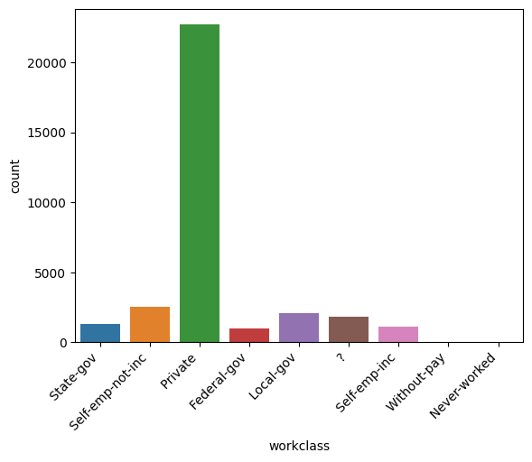

```python
ax = sns.countplot(x=p1_data["workclass"])
ax.set_xticklabels(ax.get_xticklabels(), rotation=45, ha="right")
```

From this chart, we can see that the Private workclass is the predominant class in this dataset. Without-pay and Never-worked are very small at value counts of 14 and 7, respectively. Thus, if chosen at random, there would be a higher likelihood that an individual in this dataset would be in the private workclass.

### Fnlwgt Column

**Fnlwgt Datatype**

```python
p1_data['fnlwgt'].dtype
```

```
dtype('int64')
```

**Fnlwgt Summary Statistics**

```python
p1_data['fnlwgt'].describe()
```

```
count    3.256100e+04
mean     1.897784e+05
std      1.055500e+05
min      1.228500e+04
25%      1.178270e+05
50%      1.783560e+05
75%      2.370510e+05
max      1.484705e+06
Name: fnlwgt, dtype: float64
```

**Fnlwgt Histogram**

```python
fn_values = counting_values(p1_data, 'fnlwgt')
```

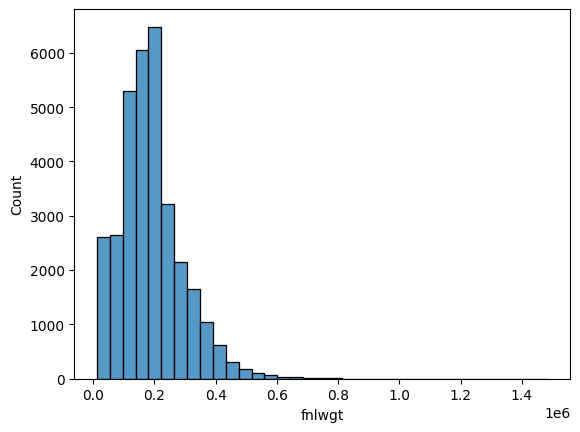

```python
sns.histplot(data=p1_data, x="fnlwgt", bins=35)
```

**Fnlwgt Boxplot**

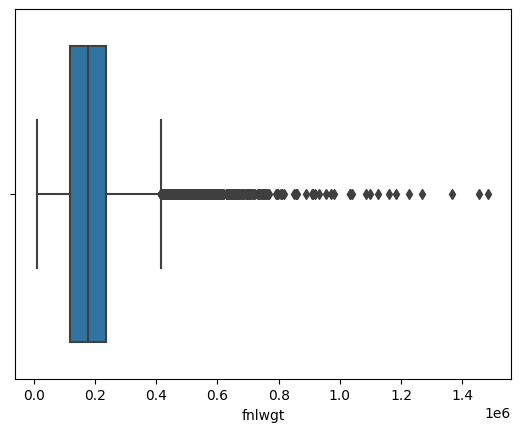

```python
sns.boxplot(x=p1_data["fnlwgt"])
```

Fnlwgt appears to be skewed to the left of the graph with most values under 0.6 and the majority around 0.2

### Education Column

**Education Datatype**

```python
p1_data['education'].dtype
```

```
dtype('O')
```

**Education Value Counts & Bar Graph**

```python
edu_values = counting_values(p1_data, 'education')
print(edu_values)
```

```
 HS-grad         10501
 Some-college     7291
 Bachelors        5355
 Masters          1723
 Assoc-voc        1382
 11th             1175
 Assoc-acdm       1067
 10th              933
 7th-8th           646
 Prof-school       576
 9th               514
 12th              433
 Doctorate         413
 5th-6th           333
 1st-4th           168
 Preschool          51
Name: education, dtype: int64
```

[output not shown]

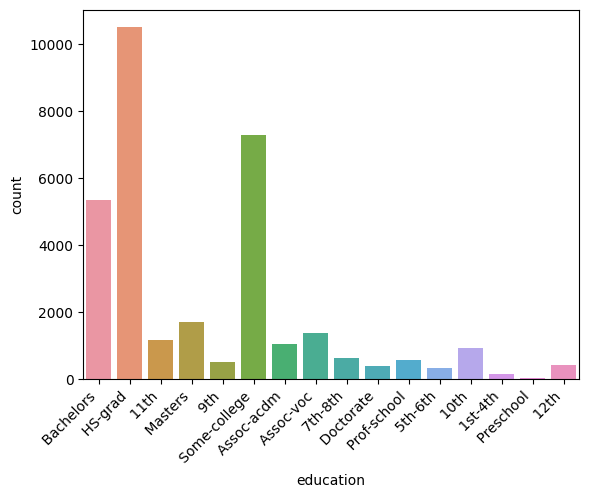

```python
ax = sns.countplot(x=p1_data["education"])
ax.set_xticklabels(ax.get_xticklabels(), rotation=45, ha="right")
```

According to this graph, the most common education type is HS-grad, with Some-college in second place and Bachelors in third place. The least common type of education type is only preschool with a count of 51 individuals. Thus, if this data set was randomnly sampled, there would be a higher liklihood that the education level of the person would be either a high school graduation, or they would have some college.

### Education-num Column

**Education-num Datatype**

```python
p1_data['education-num'].dtype
```

```
dtype('int64')
```

**Education-num Summary Statistics**

```python
p1_data['education-num'].describe()
```

```
count    32561.000000
mean        10.080679
std          2.572720
min          1.000000
25%          9.000000
50%         10.000000
75%         12.000000
max         16.000000
Name: education-num, dtype: float64
```

**Education-num Histogram & Boxplot**

```python
edu_num_values = counting_values(p1_data, 'education-num')
```

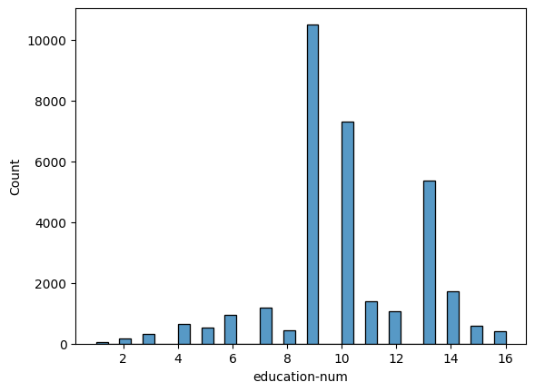

```python
sns.histplot(data=p1_data, x="education-num", bins=35)
```

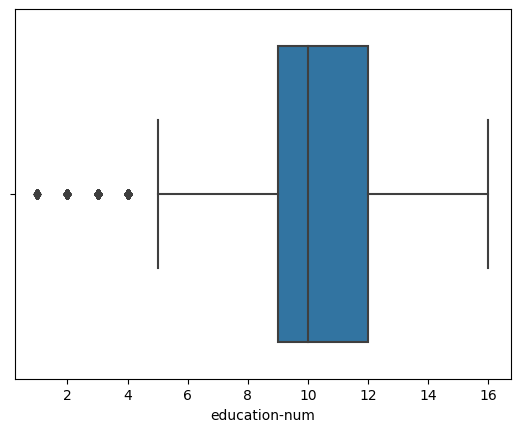

```python
sns.boxplot(x=p1_data["education-num"])
```

### Marital-status Column

**Marital-status Datatype**

```python
p1_data['marital-status'].dtype
```

```
dtype('O')
```

**Marital-status Value Counts & Bar Graph**

```python
ms_values = counting_values(p1_data, 'marital-status')
print(ms_values)
```

```
 Married-civ-spouse       14976
 Never-married            10683
 Divorced                  4443
 Separated                 1025
 Widowed                    993
 Married-spouse-absent      418
 Married-AF-spouse           23
Name: marital-status, dtype: int64
```

[output not shown]

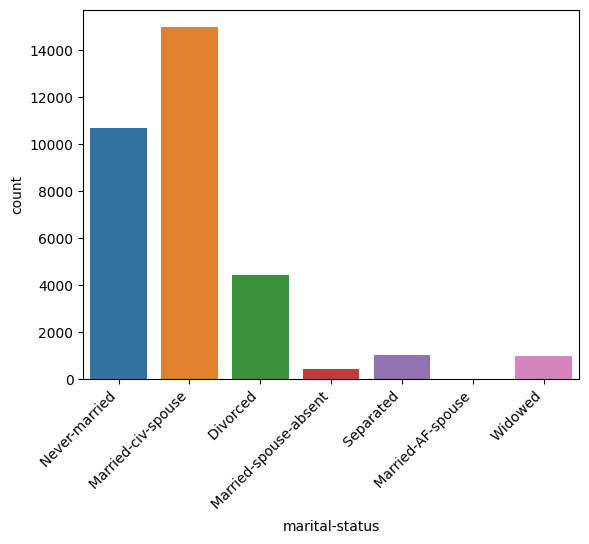

```python
ax = sns.countplot(x=p1_data["marital-status"])
ax.set_xticklabels(ax.get_xticklabels(), rotation=45, ha="right")
```

Married-civ-spouse was the most common marital-status and the Married-AF_spouse was the least common in this dataset.

### Occupation Column

**Occupation Datatype**

```python
p1_data['occupation'].dtype
```

```
dtype('O')
```

**Occupation Value Counts & Bar Graph**

```python
occ_values = counting_values(p1_data, 'occupation')
print(occ_values)
```

```
 Prof-specialty       4140
 Craft-repair         4099
 Exec-managerial      4066
 Adm-clerical         3770
 Sales                3650
 Other-service        3295
 Machine-op-inspct    2002
 ?                    1843
 Transport-moving     1597
 Handlers-cleaners    1370
 Farming-fishing       994
 Tech-support          928
 Protective-serv       649
 Priv-house-serv       149
 Armed-Forces            9
Name: occupation, dtype: int64
```

[output not shown]

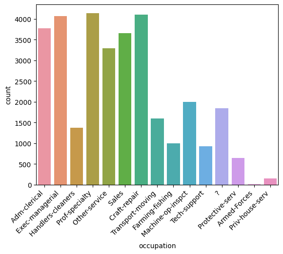

```python
ax = sns.countplot(x=p1_data["occupation"])
ax.set_xticklabels(ax.get_xticklabels(), rotation=45, ha="right")
```

The occupation column has a wide variety of fields with high counts. The Prof-specialty, Craft-repair, and Exec-managerial fields have the highest number of indivduals in this dataset. Armed-forces occupation was the least popular in this dataset.

### Relationship Column

**Relationship Datatype**

```python
p1_data['relationship'].dtype
```

```
dtype('O')
```

**Relationship Value Counts & Bar Graph**

```python
rel_values = counting_values(p1_data, 'relationship')
print(rel_values)
```

```
 Husband           13193
 Not-in-family      8305
 Own-child          5068
 Unmarried          3446
 Wife               1568
 Other-relative      981
Name: relationship, dtype: int64
```

[output not shown]

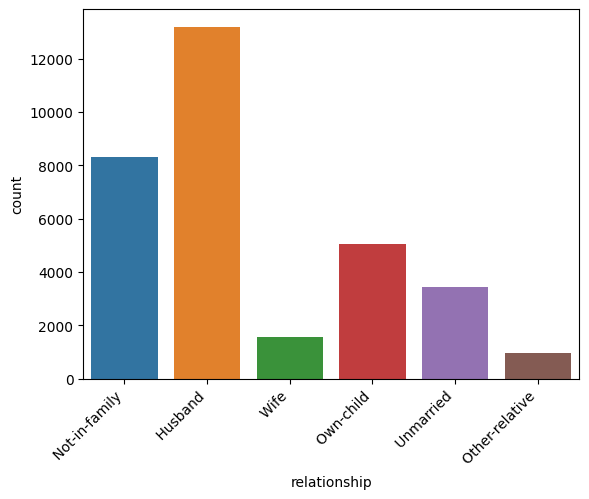

```python
ax = sns.countplot(x=p1_data["relationship"])
ax.set_xticklabels(ax.get_xticklabels(), rotation=45, ha="right")
```

Husband appears to be the highest relationship type in the data set (probably due there being more males in the dataset in general), followed by not-in-family. Other-relative is the least popular relationship type in this dataset.

### Race Column

**Race Datatype**

```python
p1_data['race'].dtype
```

```
dtype('O')
```

**Race Value Counts & Bar Graph**

```python
race_values = counting_values(p1_data, 'race')
print(race_values)
```

```
 White                 27816
 Black                  3124
 Asian-Pac-Islander     1039
 Amer-Indian-Eskimo      311
 Other                   271
Name: race, dtype: int64
```

[output not shown]

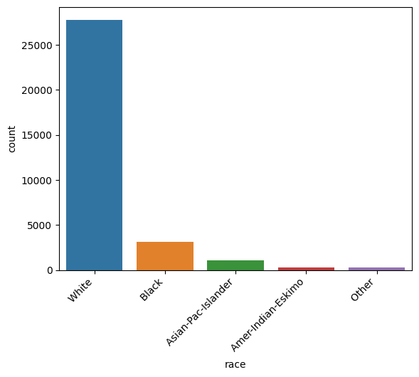

```python
ax = sns.countplot(x=p1_data["race"])
ax.set_xticklabels(ax.get_xticklabels(), rotation=45, ha="right")
```

This data set is looking at primarily white individuals, which could make the model better at predicting white-race-related data. This could introduce bias into the model.

### Sex Column

**Sex Datatype**

```python
p1_data['sex'].dtype
```

```
dtype('O')
```

**Sex Value Counts & Bar Graph**

```python
sex_values = counting_values(p1_data, 'sex')
print(sex_values)
```

```
 Male      21790
 Female    10771
Name: sex, dtype: int64
```

```
[Text(0, 0, ' Male'), Text(1, 0, ' Female')]
```

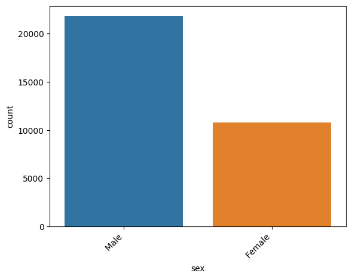

```python
ax = sns.countplot(x=p1_data["sex"])
ax.set_xticklabels(ax.get_xticklabels(), rotation=45, ha="right")
```

This data set is looking at primarily male individuals, which could make the model better at predicting male-related data. This could introduce bias into the model.

### Captial-gain Column

**Capital-gain Datatype**

```python
p1_data['capital-gain'].dtype
```

```
dtype('int64')
```

**Capital-gain Summary Statistics**

```python
p1_data['capital-gain'].describe()
```

```
count    32561.000000
mean      1077.648844
std       7385.292085
min          0.000000
25%          0.000000
50%          0.000000
75%          0.000000
max      99999.000000
Name: capital-gain, dtype: float64
```

**Capital-gain Value Counts, Histogram, & Boxplot**

```python
cg_values = counting_values(p1_data, 'capital-gain')
print(cg_values)
```

```
0        29849
15024      347
7688       284
7298       246
99999      159
         ...
1111         1
2538         1
22040        1
4931         1
5060         1
Name: capital-gain, Length: 119, dtype: int64
```

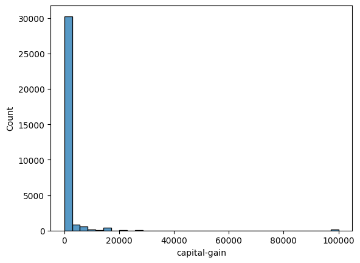

```python
sns.histplot(data=p1_data, x="capital-gain", bins=35)
```

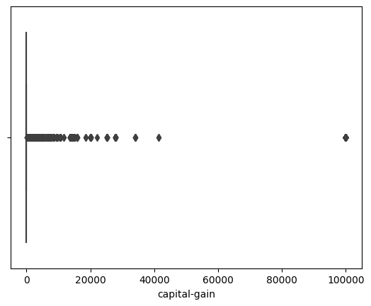

```python
sns.boxplot(x=p1_data["capital-gain"])
```

**Looking at Capital Gain With Zero Values Excluded**

```python
p1_data_copy = p1_data.copy()
```

```python
p1_data_copy = p1_data_copy[p1_data_copy['capital-gain'] != 0]
```

```python
p1_data_copy['capital-gain'].describe()
```

```
count     2712.000000
mean     12938.541298
std      22395.413530
min        114.000000
25%       3411.000000
50%       7298.000000
75%      14084.000000
max      99999.000000
Name: capital-gain, dtype: float64
```

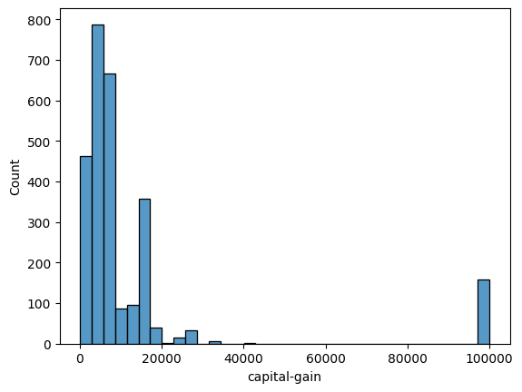

```python
sns.histplot(data=p1_data_copy, x='capital-gain', bins=35)
```

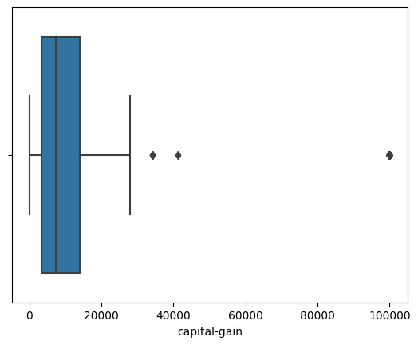

```python
sns.boxplot(x=p1_data_copy["capital-gain"])
```

Excluding those who did not have any capital gain, the mean capital gain value is at 12,938 with the majority of the distribution under 20,000. Outliers include values above around 35,000.

### Capital-loss Column

**Capial-loss Datatype**

```python
p1_data['capital-loss'].dtype
```

```
dtype('int64')
```

**Capital-loss Value Counts, Histogram, & Boxplot**

```python
cl_values = counting_values(p1_data, 'capital-loss')
```

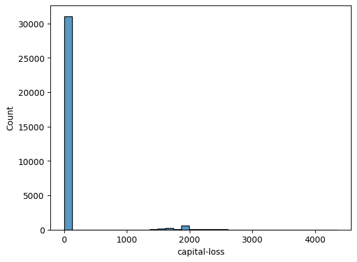

```python
sns.histplot(data=p1_data, x="capital-loss", bins=35)
```

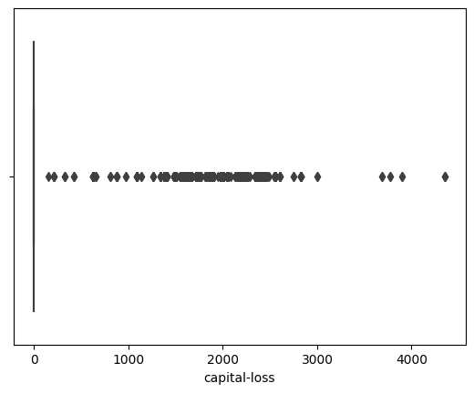

```python
sns.boxplot(x=p1_data["capital-loss"])
```

**Capital Loss With Zero Values Excluded**

```python
p1_data_copy_2 = p1_data.copy()
```

```python
p1_data_copy_2 = p1_data_copy_2[p1_data_copy_2['capital-loss'] != 0]
```

```python
p1_data_copy_2['capital-loss'].describe()
```

```
count    1519.000000
mean     1871.428571
std       376.571535
min       155.000000
25%      1672.000000
50%      1887.000000
75%      1977.000000
max      4356.000000
Name: capital-loss, dtype: float64
```

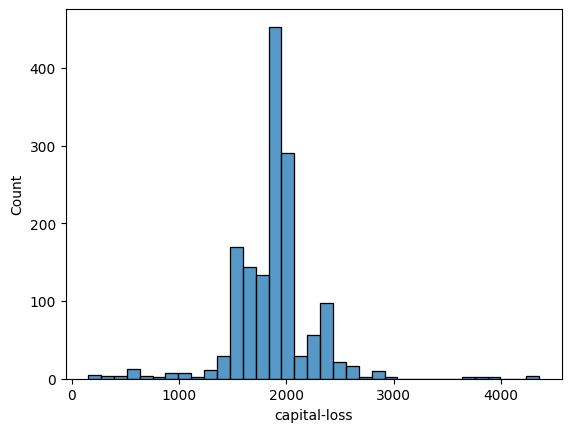

```python
sns.histplot(data=p1_data_copy_2, x='capital-loss', bins=35)
```

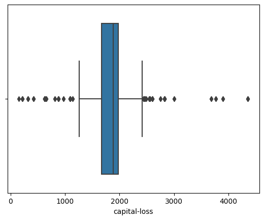

```python
sns.boxplot(x=p1_data_copy_2["capital-loss"])
```

Excluding those who did not have any capital loss, the mean capital loss value is at 1,871 with the majority of the distribution between 1,600 and 1,900. Outliers include values under around 1,100 and above around 2,500. Capital loss is much smaller than capital gain in this dataset.

### Hours-per-week Column

**Hours-per-week Datatype**

```python
p1_data['hours-per-week'].dtype
```

```
dtype('int64')
```

**Hours-per-week Summary Statistics**

```python
p1_data['hours-per-week'].describe()
```

```
count    32561.000000
mean        40.437456
std         12.347429
min          1.000000
25%         40.000000
50%         40.000000
75%         45.000000
max         99.000000
Name: hours-per-week, dtype: float64
```

**Hours-per-week Value Counts, Histogram, & Boxplot**

```python
hpw_values = counting_values(p1_data, 'hours-per-week')
```

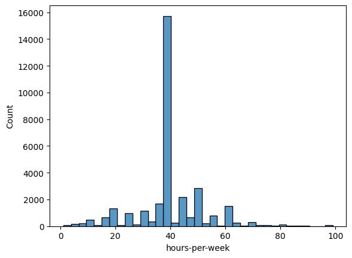

```python
sns.histplot(data=p1_data, x="hours-per-week", bins=35)
```

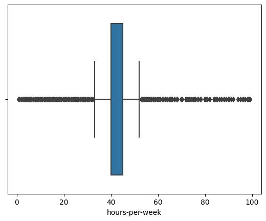

```python
sns.boxplot(x=p1_data["hours-per-week"])
```

A very large portion of individuals in this data set work at about 40 hours a week.

### Native-country Column

**Native-country Datatype**

```python
p1_data['native-country'].dtype
```

```
dtype('O')
```

**Native-country Value Counts**

```python
nc_values = counting_values(p1_data, 'native-country')
print(nc_values)
```

```
 United-States                 29170
 Mexico                          643
 ?                               583
 Philippines                     198
 Germany                         137
 Canada                          121
 Puerto-Rico                     114
 El-Salvador                     106
 India                           100
 Cuba                             95
 England                          90
 Jamaica                          81
 South                            80
 China                            75
 Italy                            73
 Dominican-Republic               70
 Vietnam                          67
 Guatemala                        64
 Japan                            62
 Poland                           60
 Columbia                         59
 Taiwan                           51
 Haiti                            44
 Iran                             43
 Portugal                         37
 Nicaragua                        34
 Peru                             31
 France                           29
 Greece                           29
 Ecuador                          28
 Ireland                          24
 Hong                             20
 Cambodia                         19
 Trinadad&Tobago                  19
 Laos                             18
 Thailand                         18
 Yugoslavia                       16
 Outlying-US(Guam-USVI-etc)       14
 Honduras                         13
 Hungary                          13
 Scotland                         12
 Holand-Netherlands                1
Name: native-country, dtype: int64
```

This data set contains mostly United States data. Thus, patterns in other countries may not be as noticeable as patterns in the United States rows since this is the majority of the data set.

## Task 3: Target Variable Exploration

### 1. Classification or Regression Task?

This data mining task is a classification task. A classification task is a supervised machine learning task, meaning it includes a target variable, labeled inputs, and outputs. The goal of a classification task is to assign an input instance into a predefined class. In this project, the goal is to predict if a certain instance is labeled <=50K or >50K based on the similarities the model finds in that instance as compared to others. The output of a classification model will be categorical.

On the other hand, while regression tasks are also supervised ML tasks, they are attempting to predict a continuous numerical value or quantity. For example, regression models may be used to predict a stock price or a product's cost.

### 2. Is the Target Variable Balanced or Imbalanced?

```python
nc_values = counting_values(p1_data, 'y')
print(nc_values)
```

```
 <=50K    24720
 >50K      7841
Name: y, dtype: int64
```

```python
p1_data.y.value_counts(normalize=True)
```

```
 <=50K    0.75919
 >50K     0.24081
Name: y, dtype: float64
```

The target variable is imbalanced as most of the rows have a y variable of <=50K (75.91%). This is significant because bias could occur in model training as the model may not be able to predict instances from the minority class since it focuses mostly on the majority class. Furthermore, the accuracy metric may be misleading because the model will have a high accuracy as it will likely predict the majority class. While most of the data falls into the majority class there are still 7,841 instances that could be misclassified. When it is important to correctly classify the minority class, the accuracy metric would not be good to rely on alone in the case of an imbalanced y variable. Because of this imbalance, the model may struggle to generalize well to new data.

```python
p1_data['y'].dtype
```

```
dtype('O')
```

```python
print(p1_data['y'].unique())
```

```
[' <=50K' ' >50K']
```

### 3. What a Majority Classifier's Accuracy Would be on This Target Variable

```
[Text(0, 0, ' <=50K'), Text(1, 0, ' >50K')]
```

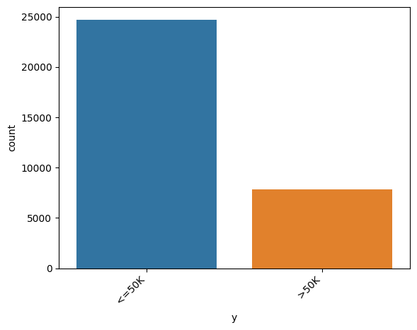

```python
ax = sns.countplot(x=p1_data["y"])
ax.set_xticklabels(ax.get_xticklabels(), rotation=45, ha="right")
```

The majority class is the <=50K class in this scenario because it has the most number of instances. Since the majority classifier would always predict the majority class we can find the accuracy by taking the number of all of the instances that belong to the majority class (24,720) and dividing it by the total number of instances. Thus, 24,720 / (24,720 + 7,841) yields 75.9% as seen in the normalized value counts code above. Therefore, any model developed in the Model Building section must have a higher accuracy than 75.9% to outperform the majority classifier.

### 4. Ranked Classification Performance Metrics to be Used

1) *F1 Score*: is a blend of precision and recall; therefore, it is a blend of how well the model can consider both false positives and false negatives. An F1 Score is calculated as follows: (2 *Precision* Recall ) / (Precision + Recall). I ranked this metric as number one because, in this case, there is not much context behind why we are classifying the variables as either two of these classes; therefore, we don't know if it would be more important for the model to more accurately classify one class over the other. Thus, F1 Score will show how the model is performing more overall.

3) *Accuracy*: is the overall correctness of the model and is calculated by taking the sum of all correct classifications and dividing by the total number of instances ( i.e. (TP + TN) / Total ). Including this metric was important so I could compare all the model's accuracies to the majority classifier's (baseline) accuracy. However, this metric is still in third place because, alone, it does not provide as good of an assessment of model performance since the target variable is imbalanced.

## Task 4: Target Exploration by Predictors & Data Encoding

## Target Exploration by Predictors

```python
numerical_predictors = ['age', 'fnlwgt', 'education-num', 'capital-gain', 'capital-loss', 'hours-per-week']

categorical_predictors = ['workclass', 'education', 'marital-status', 'occupation', 'relationship', 'race', 'sex', 'native-country']
```

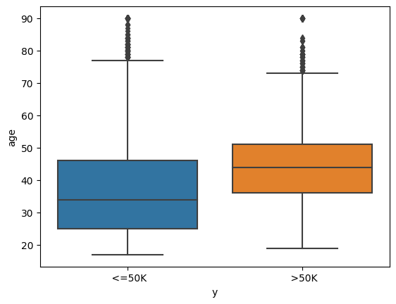

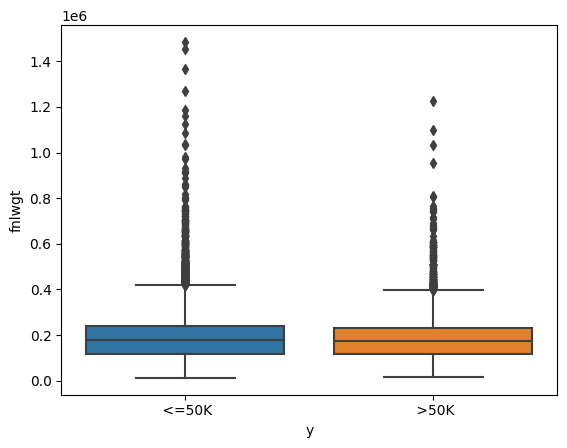

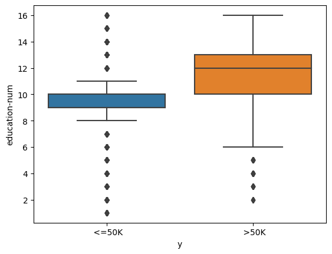

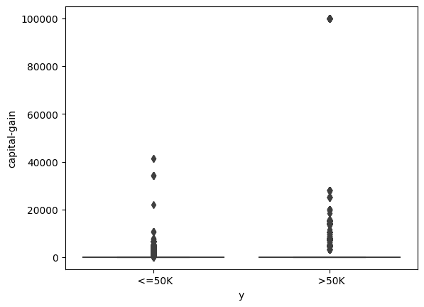

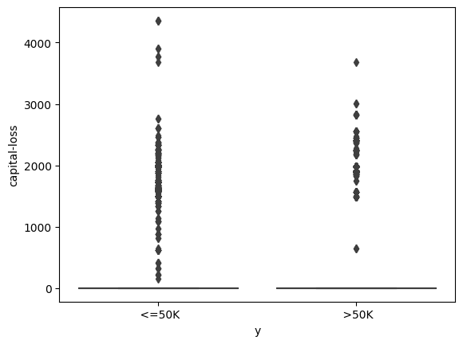

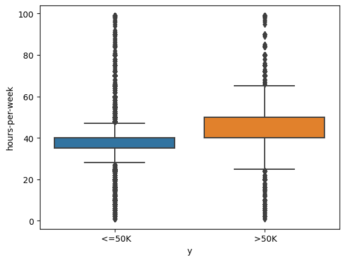

```python
for predictor in numerical_predictors:
    sns.boxplot(x='y', y=predictor, data=p1_data)
    plt.show()
```